# Module 3 | Exploratory Data Analysis and Tables

Author

A. Peralta-Santos

Published

December 28, 2023

# 1 SETUP

### 1.0.1 Limpar o ambiente

```r
rm(list = ls(all.names = TRUE))
# limpa todos os objetos, incluindo os ocultos
# boa política se houver objetos antigos não relevantes
# melhoria da performance
```

### 1.0.2 Instalar e carregar bibliotecas

Sempre que se inicia uma nova sessão, as bibliotecas têm de ser carregadas.

```r
# Forma alternativa de instalar vários pacotes e carregá-los

# SOURCE: https://cedricscherer.netlify.app/2019/05/17/the-evolution-of-a-ggplot-ep
# Packages
required_packages <- c("janitor",
                       "tidyverse",
                       "rio",
                       "data.table",
                       "lubridate",
                       "ggplot2",
                       "gt",
                       "skimr",
                       "DataExplorer"
                       )

for (pkg in required_packages) {
  # install packages if not already present
  if (!pkg %in% rownames(installed.packages())) {
    install.packages(pkg)
  }

  # load packages to this current session
  library(pkg, character.only = TRUE)
}
remove(required_packages)
remove(pkg)
```

# 2 IMPORTAÇÃO de Dados e DATA CLEANING and WRANGLING

Para esta parte da aula não será tão importante alguns passos de data cleaning e data wrangling.

## 2.1 Carregar e Limpar os dados

Continuamos a trabalhar os dados hospitalares.

```r
inpatient_hospital <- import("datasets/atividade_internamento_hospitalar.xlsx") |>
  clean_names()

inpatient_hospital_lite2 <- inpatient_hospital |>
  select(
    periodo,
    instituicao,
    tipo_de_especialidade,
    doentes_saidos,
    dias_de_internamento
  ) |>
  mutate(
    length_patient =
      round((dias_de_internamento/doentes_saidos), digits = 1),
    new_var = 2,
    fonte = "transparencia_sns",
    multiplicacao = dias_de_internamento*doentes_saidos,
    periodo=paste0(periodo, "-01"),
    periodo=as.Date(periodo, format = "%Y-%m-%d"),
    year = year(periodo),
    month=lubridate::month(periodo, label = FALSE),
    week=week(periodo),
    weekday=lubridate::wday(periodo, label=TRUE),
    tipo_instituicao =
        case_when(
          grepl("Universitário", instituicao, ignore.case = TRUE) ~ "University",
          grepl("Oncologia", instituicao, ignore.case = TRUE) ~ "Cancer hospital"
        ),
    tipo_instituicao =
      replace_na(tipo_instituicao, "Hospital")
    )

inpatient_hospital_surgery_less_500 <- inpatient_hospital_lite2 |>
  filter(tipo_de_especialidade=="Especialidade Cirurgica" &
           dias_de_internamento<=500)

covid_inc <- import("datasets/covid_inc.csv")|>
  clean_names()

hypoxia <- import("datasets/hypoxia.xlsx")|>
  clean_names()
```

# 3 EXPLORATORY DATA ANALYSIS

O passo da Exploração dos Dados (EDA em inglês), por si, não é um processo formal com regras de execução.

> “There are no routine statistical questions, only questionable statistical routines.” — Sir David Cox

É um processo de exploração da curiosidade despoletado pelos dados que temos à nossa frente.

É um passo necessário na investigação da qualidade dos dados.

É um processo iterativo no qual:

1. Geramos questões sobre os dados;
2. Procuramos responder às questões que temos através de simples:
- Visualizações
- Transformações
- Modelação
3. Assimilamos o que aprendemos e refinamos/geramos novas questões

## 3.1 FORMULAR QUESTÕES

Pré-requisitos:

- Conhecer os dados que temos
- Se não conhecemos, ver os metadados
- Começar uma análise já com questões com resposta nos dados que temos
- Colocar hipóteses, garante que expomos os nossos presupostos na análise
- Colocar múltiplas questões é melhor que uma questão

## 3.2 VER OS CONTEÚDOS

Estas primeiras funções não dirão muito mas permitem ter uma melhor compreensão ds dados que temos á frente.

Números de linhas

```r
nrow(inpatient_hospital)
```

```
[1] 7746
```

Temos 7746 observações.

Número de Colunas

```r
ncol(inpatient_hospital)
```

```
[1] 7
```

```r
# esta função resume as duas questões anteriores
dim(inpatient_hospital)
```

```
[1] 7746    7
```

Para além do número de registos, podemos querer saber o nome e o tipo de variável importados.

Nome das colunas

```r
colnames(inpatient_hospital)
```

```
[1] "periodo"                "regiao"                 "instituicao"
[4] "localizacao_geografica" "tipo_de_especialidade"  "doentes_saidos"
[7] "dias_de_internamento"
```

```r
length(inpatient_hospital)
```

```
[1] 7
```

Nos dados originais temos 7 variáveis: - periodo - regiao - instituicao - tipo de especialidade - localização geográfica - dias de internamento - doentes saidos

Tipo de Variável

```r
str(inpatient_hospital)
```

```
'data.frame':   7746 obs. of  7 variables:
 $ periodo               : chr  "2015-01" "2015-01" "2015-01" "2015-01" ...
 $ regiao                : chr  "Região de Saúde do Alentejo" "Região de Saúde do Centro" "Região de Saúde do Centro" "Região de Saúde do Centro" ...
 $ instituicao           : chr  "Unidade Local de Saúde do Baixo Alentejo, EPE" "Centro Hospitalar Universitário Cova da Beira, EPE" "Centro Hospitalar do Baixo Vouga, EPE" "Instituto Português Oncologia de Coimbra, EPE" ...
 $ localizacao_geografica: chr  "38.014123, -7.8721227" "40.2804158, -7.4922407" "40.6362453, -8.6543716" "40.2162514, -8.4103814" ...
 $ tipo_de_especialidade : chr  "Especialidade Cirurgica" "Especialidade Cirurgica" "Especialidade Cirurgica" "Especialidade Cirurgica" ...
 $ doentes_saidos        : num  360 352 651 330 329 ...
 $ dias_de_internamento  : num  2026 2626 3958 2183 2640 ...
```

Com os dados do str sabemos que:

- periodo
- regiao
- instituicao
- localização geográfica
- tipo de especialidade

Temos duas variáveis numéricas:

- doentes saidos
- dias de internamentos

Embora as variáveis numéricas façam sentido, nas nominais podemos querer alterar algumas coisas:

- Mudar periodo para data
- Mudar a regiao, instituicao e tipo de especialidade para fatores para análises estatísticas subsequentes
- Para já não temos questões relativas à localização geográfica, por isso podemos remover esta variável

```r
inpatient_hospital_lite <- inpatient_hospital |>
  select(
    -localizacao_geografica # remover localização
  ) |>
  mutate(
    periodo=paste0(periodo, "-01"), # modificar periodo para que possa ser lido como data
    periodo=as.Date(periodo, format = "%Y-%m-%d"), #informar que periodo é data
    regiao= as_factor(regiao), # existe uma função para fatores ordinais que é ordered() mas que neste caso não é útil
    instituicao= as_factor(instituicao),
    tipo_de_especialidade=as_factor(tipo_de_especialidade))
```

Vamos confirmar as alterações com o str

```r
str(inpatient_hospital_lite)
```

```
'data.frame':   7746 obs. of  6 variables:
 $ periodo              : Date, format: "2015-01-01" "2015-01-01" ...
 $ regiao               : Factor w/ 5 levels "Região de Saúde do Alentejo",..: 1 2 2 2 2 3 4 4 4 4 ...
 $ instituicao          : Factor w/ 51 levels "Unidade Local de Saúde do Baixo Alentejo, EPE",..: 1 2 3 4 5 6 7 8 9 10 ...
 $ tipo_de_especialidade: Factor w/ 2 levels "Especialidade Cirurgica",..: 1 1 1 1 1 1 1 1 1 1 ...
 $ doentes_saidos       : num  360 352 651 330 329 ...
 $ dias_de_internamento : num  2026 2626 3958 2183 2640 ...
```

Agora já temos um melhor conhecimento sobre os dados:

- Uma variável de Data
- 3 variáveis são fatores
  - Regiao com 5 valores possíveis
  - Intituicão com 51 valores possíveis
  - Tipo de especialidade com 2 valores posssíveis

## 3.3 PREVISUALIZAR OS DADOS

Uma boa prática numa primeira fase é visualizar pequenas porções dos dados para ver possíveis problemas imediatamente.

### 3.3.1 Função HEAD() e TAIL()

Estas funções expõe n linhas dos dados.

```r
head(inpatient_hospital_lite)
```

```
     periodo                      regiao
1 2015-01-01 Região de Saúde do Alentejo
2 2015-01-01   Região de Saúde do Centro
3 2015-01-01   Região de Saúde do Centro
4 2015-01-01   Região de Saúde do Centro
5 2015-01-01   Região de Saúde do Centro
6 2015-01-01         Região de Saúde LVT
                                         instituicao   tipo_de_especialidade
1      Unidade Local de Saúde do Baixo Alentejo, EPE Especialidade Cirurgica
2 Centro Hospitalar Universitário Cova da Beira, EPE Especialidade Cirurgica
3              Centro Hospitalar do Baixo Vouga, EPE Especialidade Cirurgica
4      Instituto Português Oncologia de Coimbra, EPE Especialidade Cirurgica
5              Unidade Local de Saúde da Guarda, EPE Especialidade Cirurgica
6                  Centro Hospitalar de Setúbal, EPE Especialidade Cirurgica
  doentes_saidos dias_de_internamento
1            360                 2026
2            352                 2626
3            651                 3958
4            330                 2183
5            329                 2640
6            525                 3442
```

```r
tail(inpatient_hospital_lite)
```

```
        periodo                regiao
7741 2022-01-01   Região de Saúde LVT
7742 2022-01-01 Região de Saúde Norte
7743 2022-01-01 Região de Saúde Norte
7744 2022-01-01 Região de Saúde Norte
7745 2022-01-01 Região de Saúde Norte
7746 2022-01-01 Região de Saúde Norte
                                            instituicao tipo_de_especialidade
7741       Instituto Português Oncologia de Lisboa, EPE  Especialidade Médica
7742                Centro Hospitalar do Médio Ave, EPE  Especialidade Médica
7743 Centro Hospitalar Trás-os-Montes e Alto Douro, EPE  Especialidade Médica
7744                             Hospital de Braga, EPE  Especialidade Médica
7745        Instituto Português Oncologia do Porto, EPE  Especialidade Médica
7746          Unidade Local de Saúde do Alto Minho, EPE  Especialidade Médica
     doentes_saidos dias_de_internamento
7741            491                 3488
7742            361                 4806
7743           1103                 8243
7744            904                 9555
7745            328                 3239
7746            507                 4631
```

Pelos dados do Head e do Tail verificamos que os dados:

- Estão orientados de forma ascendente pelo período
- Parecem ir das Especialidade Cirúrgicas para as Médicas
- Os valores da variável dias de internamento parecem ser maiores

### 3.3.2 GT (preview)

Um dos maiores pacotes para geração de tabelas permite de forma simples fazer o mesmo que as funções head e tail numa tabela.

```r
inpatient_hospital_lite |>
  gt_preview(top_n=5, bottom_n = 5)
```

|  | periodo | regiao | instituicao | tipo_de_especialidade | doentes_saidos | dias_de_internamento |
| --- | --- | --- | --- | --- | --- | --- |
| 1 | 2015-01-01 | Região de Saúde do Alentejo | Unidade Local de Saúde do Baixo Alentejo, EPE | Especialidade Cirurgica | 360 | 2026 |
| 2 | 2015-01-01 | Região de Saúde do Centro | Centro Hospitalar Universitário Cova da Beira, EPE | Especialidade Cirurgica | 352 | 2626 |
| 3 | 2015-01-01 | Região de Saúde do Centro | Centro Hospitalar do Baixo Vouga, EPE | Especialidade Cirurgica | 651 | 3958 |
| 4 | 2015-01-01 | Região de Saúde do Centro | Instituto Português Oncologia de Coimbra, EPE | Especialidade Cirurgica | 330 | 2183 |
| 5 | 2015-01-01 | Região de Saúde do Centro | Unidade Local de Saúde da Guarda, EPE | Especialidade Cirurgica | 329 | 2640 |
| 6..7741 |  |  |  |  |  |  |
| 7742 | 2022-01-01 | Região de Saúde Norte | Centro Hospitalar do Médio Ave, EPE | Especialidade Médica | 361 | 4806 |
| 7743 | 2022-01-01 | Região de Saúde Norte | Centro Hospitalar Trás-os-Montes e Alto Douro, EPE | Especialidade Médica | 1103 | 8243 |
| 7744 | 2022-01-01 | Região de Saúde Norte | Hospital de Braga, EPE | Especialidade Médica | 904 | 9555 |
| 7745 | 2022-01-01 | Região de Saúde Norte | Instituto Português Oncologia do Porto, EPE | Especialidade Médica | 328 | 3239 |
| 7746 | 2022-01-01 | Região de Saúde Norte | Unidade Local de Saúde do Alto Minho, EPE | Especialidade Médica | 507 | 4631 |

### 3.3.3 Summary

A função mais conhecia para a estatística descritiva no R, é o summary(), que dá a amplitude dos dados, a média e mediana dos dados, porém não mede o tamanho amostral total, o tipo de distribição nem disperção dos dados.

```r
summary(inpatient_hospital_lite)
```

```
    periodo                                   regiao
 Min.   :2015-01-01   Região de Saúde do Alentejo: 680
 1st Qu.:2016-10-01   Região de Saúde do Centro  :1797
 Median :2018-07-01   Região de Saúde LVT        :2465
 Mean   :2018-07-03   Região de Saúde Norte      :2634
 3rd Qu.:2020-04-01   Região de Saúde do Algarve : 170
 Max.   :2022-01-01

                                             instituicao
 Unidade Local de Saúde do Baixo Alentejo, EPE     : 170
 Centro Hospitalar Universitário Cova da Beira, EPE: 170
 Centro Hospitalar do Baixo Vouga, EPE             : 170
 Instituto Português Oncologia de Coimbra, EPE     : 170
 Unidade Local de Saúde da Guarda, EPE             : 170
 Centro Hospitalar de Setúbal, EPE                 : 170
 (Other)                                           :6726
             tipo_de_especialidade doentes_saidos  dias_de_internamento
 Especialidade Cirurgica:3740      Min.   :    3   Min.   :    46
 Especialidade Médica   :4006      1st Qu.: 1474   1st Qu.: 11770
                                   Median : 3185   Median : 24957
                                   Mean   : 4374   Mean   : 35756
                                   3rd Qu.: 5909   3rd Qu.: 47372
                                   Max.   :34354   Max.   :259313
                                   NA's   :2
```

Com mais esta função aprofundamos mais o nosso conhecimento dos dados:

- A data vai de janeiro de 2015 a janeiro de 2022 e parece ser mensal que o ponto médio é julho de 2018
- Existem mais registos de LVT e Norte (possivel razão?)
- Parecem haver 170 registos por hospital
- Existem mais registos de Especialidades Médicas do que de Cirúrgicas
- Os doentes saídos têm 2 valores em falta
- As distribuições das variáveis dos doentes saidos e dos dias de internamento têm uma variabilidade

### 3.3.4 Ver os números por hospital

```r
inp_hosp_lite_count <- inpatient_hospital_lite |>
  summarise(
            count= n(),
            total_patients= sum(doentes_saidos, na.rm = TRUE),
            mean_patients = mean(doentes_saidos, na.rm = TRUE),
            sd_patients = sd(doentes_saidos, na.rm = TRUE),
            median_patients = median(doentes_saidos, na.rm = TRUE),
            iqr_patients = IQR(doentes_saidos, na.rm = TRUE),
  .by = instituicao) |>
   arrange(count)

inp_hosp_lite_count
```

```
                                                     instituicao count
1                                        Hospital de Loures, EPE     2
2                             Hospital Arcebispo João Crisóstomo    12
3                           Hospital de Vila Franca de Xira, EPE    16
4                                         Hospital de Braga, EPE    58
5                               Hospital de Magalhães Lemos, EPE    84
6  Centro Medicina de Reabilitação da Região Centro Rovisco Pais    85
7                       Centro Hospitalar Psiquiátrico de Lisboa    85
8                                         Hospital de Braga, PPP   112
9                           Hospital de Vila Franca de Xira, PPP   154
10                                       Hospital de Loures, PPP   168
11                 Unidade Local de Saúde do Baixo Alentejo, EPE   170
12            Centro Hospitalar Universitário Cova da Beira, EPE   170
13                         Centro Hospitalar do Baixo Vouga, EPE   170
14                 Instituto Português Oncologia de Coimbra, EPE   170
```

[output cut: 89 more lines]

Quais são algumas considerações que podemos fazer sobre estes dados?

## 3.4 VARIATION

A variação é a tendência dos dados variarem por medições consecutivas ou por sujeitos ou tempos.

Vamos explorar questões iniciais:

- Qual é a variação de doentes saídos por hospital
- Qual a diferença da distribuição de dados entre 2015 e 2022
- Qual é a variação dos dados por Tipo de Especialidade.

Como a variável doentes de doentes saidos é numérica podemos explorar a sua distribuição através do uso de histogramas. Em módulos futuros iremos explorar como fazer código e como melhorar gráficos apresentados.

O objetivo desta fase é explorar os valores mais típicos e procurar valores inesperados.

Perguntas desta fase podem ser:

- Quais são os valores mais comuns? Razões para isso?
- Quais valores são mais raros? Porquê serão?
- É possível observar algum padrão incomum?

Qual é a variação de doentes saídos por hospital

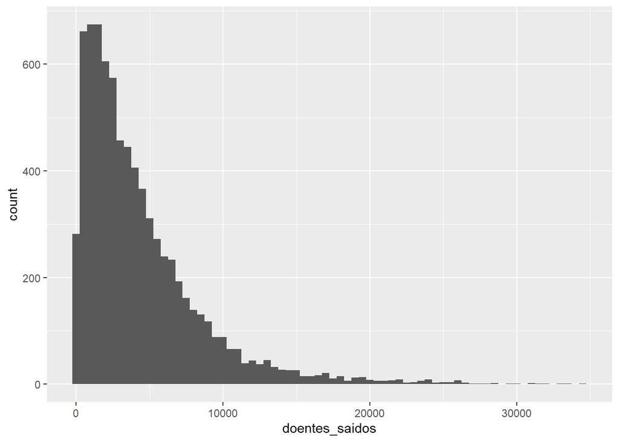

```r
p1 <- inpatient_hospital_lite |>
  ggplot(aes(x=doentes_saidos))+
    geom_histogram(binwidth = 500)#isto cria um histograma com intervalos de 500 doentes

p1
```

Qual a diferença da distribuição de dados entre 2015 e 2022

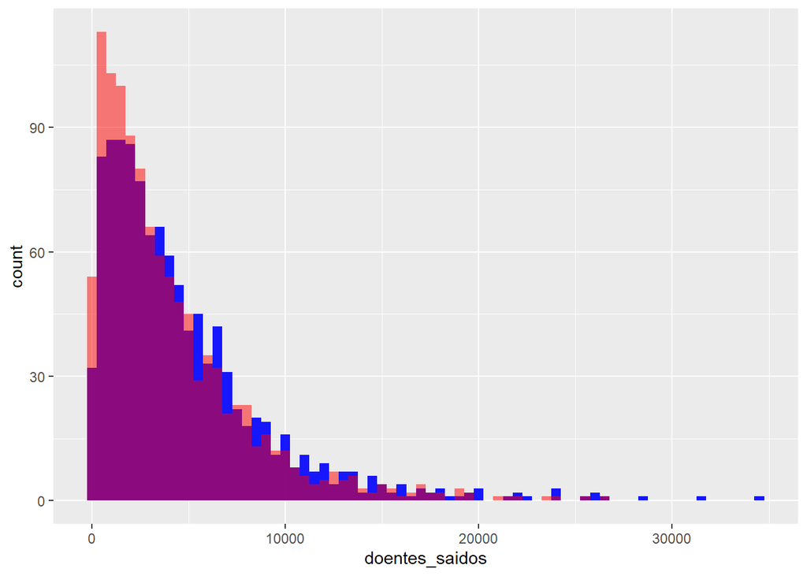

```r
p1 <- ggplot()+
    geom_histogram(data=inpatient_hospital_lite |> filter(periodo<"2016-01-01"),aes(x=doentes_saidos), binwidth = 500, fill="blue", alpha=0.9)+#isto cria um histograma com intervalos de 500 doentes
    geom_histogram(data=inpatient_hospital_lite |> filter(periodo>"2021-01-01"),aes(x=doentes_saidos), binwidth = 500, fill="red", alpha=0.5)

p1
```

Os dados de 2021 aparentem ter uma maior frequência de valores mais baixos que 2015.

Qual é a variação dos dados por Tipo de Especialidade

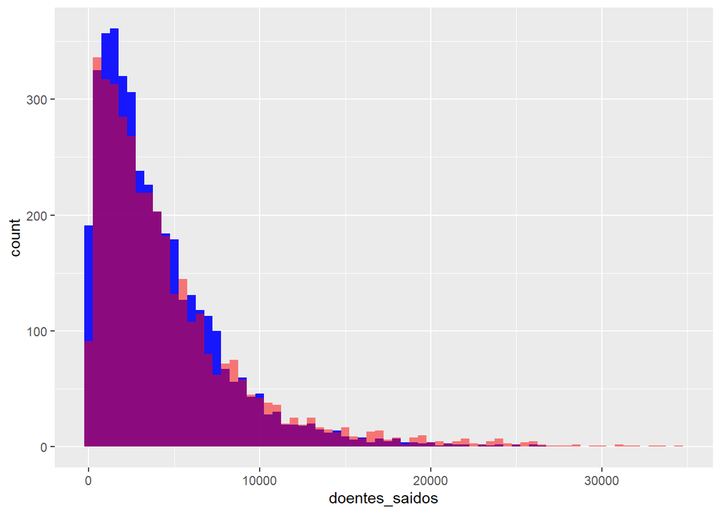

```r
p1 <- ggplot()+
    geom_histogram(data=inpatient_hospital_lite |> filter(tipo_de_especialidade=="Especialidade Médica"),aes(x=doentes_saidos), binwidth = 500, fill="blue", alpha=0.9)+#isto cria um histograma com intervalos de 500 doentes
    geom_histogram(data=inpatient_hospital_lite |> filter(tipo_de_especialidade=="Especialidade Cirurgica"),aes(x=doentes_saidos), binwidth = 500, fill="red", alpha=0.5)

p1
```

As Especialidades Médicas aparentem ter uma distribuição mais equilibrada de valores e os valores mais elevados parecem advir de valores de Especialidades Cirúrgicas.

Outras questões?

- Existem padrões diferentes nos hospitais centrais e periféricos?
- Existem diferenças entre os dados de Dezembro e de Junho?

## 3.5 VALORES INCOMUNS ou IMPOSSÍVEIS

Pelos dados do summary sabemos que existem dados em falta e existem valores muito elevados que poderão ser outliers.

Estes dados podem ajudar a fazer novas inferências sobre os dados que temos.

### 3.5.1 Valores Omissos

Para filtrarmos os dados em falta iremos utilizar a função is.na().

```r
inpatient_hospital_na <- inpatient_hospital_lite |>
  filter(is.na(doentes_saidos))

inpatient_hospital_na
```

```
     periodo                    regiao                           instituicao
1 2018-10-01 Região de Saúde do Centro Unidade Local de Saúde da Guarda, EPE
2 2018-10-01 Região de Saúde do Centro Unidade Local de Saúde da Guarda, EPE
    tipo_de_especialidade doentes_saidos dias_de_internamento
1    Especialidade Médica             NA                45164
2 Especialidade Cirurgica             NA                21215
```

Pela tabela podemos ver que a Unidade Local de Saúde da Guarda, EPE não reportou dados de doentes saidos.

Será porque foram 0? Sera porque não reportaram dados?

```r
inpatient_hospital_zero <- inpatient_hospital_lite |>
  filter(doentes_saidos<10)

inpatient_hospital_zero
```

```
     periodo                    regiao                        instituicao
1 2021-01-01 Região de Saúde do Centro Hospital Arcebispo João Crisóstomo
  tipo_de_especialidade doentes_saidos dias_de_internamento
1  Especialidade Médica              3                   49
```

Não existem valore codificados para 0, sendo que o valor mínimo é de 3.

### 3.5.2 Valores extremos OUTLIERS

$$I=[q0.25−1.5⋅IQR;q0.75+1.5⋅IQR]$$

Tendo em conta os dados dos histogramas acima, vamo-nos focar nos dados de Especialidade Cirúrgica.

```r
inpatient_hospital_outliers <- inpatient_hospital_lite |>
  filter(tipo_de_especialidade=="Especialidade Cirurgica")

summary(inpatient_hospital_outliers)
```

```
    periodo                                   regiao
 Min.   :2015-01-01   Região de Saúde do Alentejo: 340
 1st Qu.:2016-10-01   Região de Saúde do Centro  : 850
 Median :2018-07-01   Região de Saúde LVT        :1190
 Mean   :2018-07-01   Região de Saúde Norte      :1275
 3rd Qu.:2020-04-01   Região de Saúde do Algarve :  85
 Max.   :2022-01-01

                                             instituicao
 Unidade Local de Saúde do Baixo Alentejo, EPE     :  85
 Centro Hospitalar Universitário Cova da Beira, EPE:  85
 Centro Hospitalar do Baixo Vouga, EPE             :  85
 Instituto Português Oncologia de Coimbra, EPE     :  85
 Unidade Local de Saúde da Guarda, EPE             :  85
 Centro Hospitalar de Setúbal, EPE                 :  85
 (Other)                                           :3230
             tipo_de_especialidade doentes_saidos  dias_de_internamento
 Especialidade Cirurgica:3740      Min.   :   11   Min.   :    46
 Especialidade Médica   :   0      1st Qu.: 1578   1st Qu.:  9657
                                   Median : 3333   Median : 20604
                                   Mean   : 4693   Mean   : 29755
                                   3rd Qu.: 6184   3rd Qu.: 37950
                                   Max.   :34354   Max.   :240442
                                   NA's   :1
```

```r
q25 <- 1578
q75 <- 6184
median <- 3333
iqr <- q75-q25

inpatient_hospital_outliers <- inpatient_hospital_lite |>
  filter(doentes_saidos>median+1.5*iqr|doentes_saidos<median-1.5*iqr)

nrow(inpatient_hospital_outliers)
```

```
[1] 627
```

Existem 627 valores que são outliers.

```r
q25 <- 1578
q75 <- 6184
median <- 3333
iqr <- q75-q25

inpatient_hospital_outliers <- inpatient_hospital_lite |>
  filter(doentes_saidos>median+3*iqr|doentes_saidos<median-3*iqr)

nrow(inpatient_hospital_outliers)
```

```
[1] 158
```

Existem 158 valores que são outliers.

Vamos olhar para os valores superiores e ver que hospitais reportam estes valores.

```r
q25 <- 1578
q75 <- 6184
median <- 3333
iqr <- q75-q25

inpatient_hospital_outliers_nome <- inpatient_hospital_lite |>
  filter(doentes_saidos>median+3*iqr) |>
  distinct(instituicao) |>
  pull(instituicao)

inpatient_hospital_outliers_nome
```

```
[1] Centro Hospitalar Universitário do Porto, EPE
[2] Centro Hospitalar Universitário Lisboa Central, EPE
[3] Centro Hospitalar e Universitário de Coimbra, EPE
[4] Centro Hospitalar Universitário de São João, EPE
[5] Hospital de Braga, EPE
[6] Centro Hospitalar Universitário de Lisboa Norte, EPE
51 Levels: Unidade Local de Saúde do Baixo Alentejo, EPE ...
```

Existem 6 hospitiais que reportam valores outliers severos superiores.

1. Centro Hospitalar Universitário do Porto, EPE
2. Centro Hospitalar Universitário Lisboa Central, EPE
3. Centro Hospitalar e Universitário de Coimbra, EPE
4. Centro Hospitalar Universitário de São João, EPE
5. Hospital de Braga, EPE
6. Centro Hospitalar Universitário de Lisboa Norte, EPE

## 3.6 Covariação

A variação é o comportamento em relação a uma variável. A covariação é a tendência dos valores de uma varíavel estarem relacionados

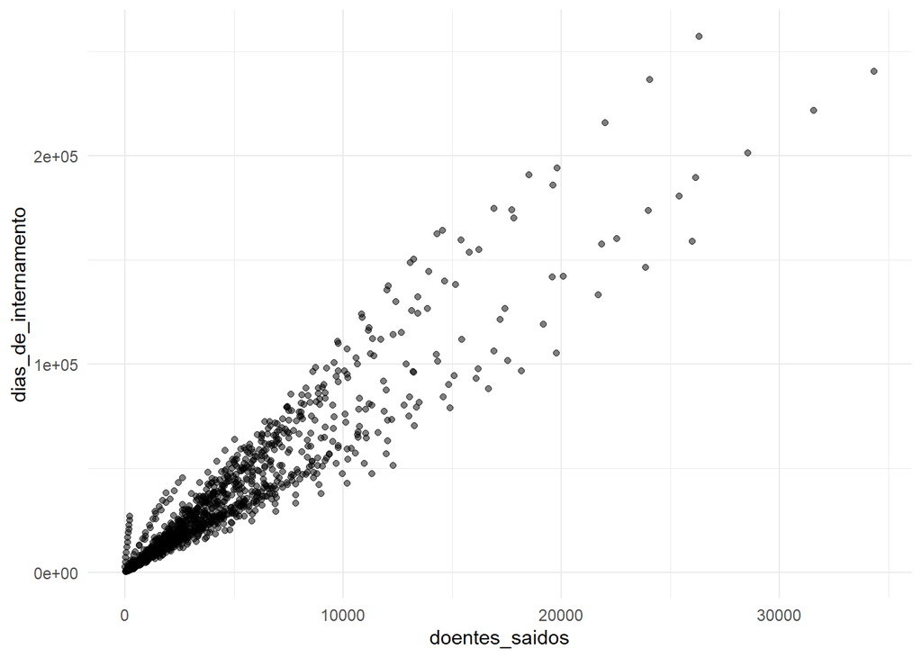

```r
ggplot(data = inpatient_hospital_lite |> filter(periodo<"2016-01-01"),
       aes(x=doentes_saidos, y=dias_de_internamento)) +
  geom_point(alpha=0.5) +
  theme_minimal()
```

Parece existir uma tendência positiva entre os doentes saidos e os dias de internamentos.

# 4 FERRAMENTAS DE EXPLORAÇÃO RÁPIDA

## 4.1 SkimR

Para um EDA mais eficiente existem já pacotes criados como o Skimr.

Este pacote calcula logo:

- Número de dados em falta
- Média
- Mediana
- Desvio-Padrão
- Q0, Q25, Q50, Q75 e Q100

```r
skim(inpatient_hospital_lite)
```

Data summary

| Name | inpatient_hospital_lite |
| --- | --- |
| Number of rows | 7746 |
| Number of columns | 6 |
| _______________________ |  |
| Column type frequency: |  |
| Date | 1 |
| factor | 3 |
| numeric | 2 |
| ________________________ |  |
| Group variables | None |

**Variable type: Date**

| skim_variable | n_missing | complete_rate | min | max | median | n_unique |
| --- | --- | --- | --- | --- | --- | --- |
| periodo | 0 | 1 | 2015-01-01 | 2022-01-01 | 2018-07-01 | 85 |

**Variable type: factor**

| skim_variable | n_missing | complete_rate | ordered | n_unique | top_counts |
| --- | --- | --- | --- | --- | --- |
| regiao | 0 | 1 | FALSE | 5 | Reg: 2634, Reg: 2465, Reg: 1797, Reg: 680 |
| instituicao | 0 | 1 | FALSE | 51 | Uni: 170, Cen: 170, Cen: 170, Ins: 170 |
| tipo_de_especialidade | 0 | 1 | FALSE | 2 | Esp: 4006, Esp: 3740 |

**Variable type: numeric**

| skim_variable | n_missing | complete_rate | mean | sd | p0 | p25 | p50 | p75 | p100 | hist |
| --- | --- | --- | --- | --- | --- | --- | --- | --- | --- | --- |
| doentes_saidos | 2 | 1 | 4374.48 | 4197.93 | 3 | 1473.75 | 3185 | 5909.0 | 34354 | ▇▂▁▁▁ |
| dias_de_internamento | 0 | 1 | 35756.06 | 35219.47 | 46 | 11770.25 | 24957 | 47371.5 | 259313 | ▇▂▁▁▁ |

Por Especialidade

```r
inpatient_hospital_lite |>
  group_by(tipo_de_especialidade) |>
  select(-dias_de_internamento, -periodo) |>
  skim()
```

Data summary

| Name | select(…) |
| --- | --- |
| Number of rows | 7746 |
| Number of columns | 4 |
| _______________________ |  |
| Column type frequency: |  |
| factor | 2 |
| numeric | 1 |
| ________________________ |  |
| Group variables | tipo_de_especialidade |

**Variable type: factor**

| skim_variable | tipo_de_especialidade | n_missing | complete_rate | ordered | n_unique | top_counts |
| --- | --- | --- | --- | --- | --- | --- |
| regiao | Especialidade Cirurgica | 0 | 1 | FALSE | 5 | Reg: 1275, Reg: 1190, Reg: 850, Reg: 340 |
| regiao | Especialidade Médica | 0 | 1 | FALSE | 5 | Reg: 1359, Reg: 1275, Reg: 947, Reg: 340 |
| instituicao | Especialidade Cirurgica | 0 | 1 | FALSE | 47 | Uni: 85, Cen: 85, Cen: 85, Ins: 85 |
| instituicao | Especialidade Médica | 0 | 1 | FALSE | 51 | Uni: 85, Cen: 85, Cen: 85, Ins: 85 |

**Variable type: numeric**

| skim_variable | tipo_de_especialidade | n_missing | complete_rate | mean | sd | p0 | p25 | p50 | p75 | p100 | hist |
| --- | --- | --- | --- | --- | --- | --- | --- | --- | --- | --- | --- |
| doentes_saidos | Especialidade Cirurgica | 1 | 1 | 4693.22 | 4658.64 | 11 | 1577.5 | 3333 | 6183.5 | 34354 | ▇▂▁▁▁ |
| doentes_saidos | Especialidade Médica | 1 | 1 | 4076.91 | 3692.47 | 3 | 1419.0 | 3056 | 5726.0 | 26335 | ▇▂▁▁▁ |

Por instituição

```r
inpatient_hospital_lite |>
  group_by(instituicao) |>
  select(-dias_de_internamento, -periodo) |>
  skim()
```

Data summary

| Name | select(…) |
| --- | --- |
| Number of rows | 7746 |
| Number of columns | 4 |
| _______________________ |  |
| Column type frequency: |  |
| factor | 2 |
| numeric | 1 |
| ________________________ |  |
| Group variables | instituicao |

**Variable type: factor**

| skim_variable | instituicao | n_missing | complete_rate | ordered | n_unique | top_counts |
| --- | --- | --- | --- | --- | --- | --- |
| regiao | Unidade Local de Saúde do Baixo Alentejo, EPE | 0 | 1 | FALSE | 1 | Reg: 170, Reg: 0, Reg: 0, Reg: 0 |
| regiao | Centro Hospitalar Universitário Cova da Beira, EPE | 0 | 1 | FALSE | 1 | Reg: 170, Reg: 0, Reg: 0, Reg: 0 |
| regiao | Centro Hospitalar do Baixo Vouga, EPE | 0 | 1 | FALSE | 1 | Reg: 170, Reg: 0, Reg: 0, Reg: 0 |
| regiao | Instituto Português Oncologia de Coimbra, EPE | 0 | 1 | FALSE | 1 | Reg: 170, Reg: 0, Reg: 0, Reg: 0 |
| regiao | Unidade Local de Saúde da Guarda, EPE | 0 | 1 | FALSE | 1 | Reg: 170, Reg: 0, Reg: 0, Reg: 0 |
| regiao | Centro Hospitalar de Setúbal, EPE | 0 | 1 | FALSE | 1 | Reg: 170, Reg: 0, Reg: 0, Reg: 0 |
| regiao | Centro Hospitalar Universitário de São João, EPE | 0 | 1 | FALSE | 1 | Reg: 170, Reg: 0, Reg: 0, Reg: 0 |
| regiao | Centro Hospitalar do Médio Ave, EPE | 0 | 1 | FALSE | 1 | Reg: 170, Reg: 0, Reg: 0, Reg: 0 |
| regiao | Centro Hospitalar Entre Douro e Vouga, EPE | 0 | 1 | FALSE | 1 | Reg: 170, Reg: 0, Reg: 0, Reg: 0 |
| regiao | Hospital Santa Maria Maior, EPE | 0 | 1 | FALSE | 1 | Reg: 170, Reg: 0, Reg: 0, Reg: 0 |
| regiao | Centro Hospitalar Universitário do Algarve,EPE | 0 | 1 | FALSE | 1 | Reg: 170, Reg: 0, Reg: 0, Reg: 0 |
| regiao | Hospital Dr. Francisco Zagalo | 0 | 1 | FALSE | 1 | Reg: 170, Reg: 0, Reg: 0, Reg: 0 |
| regiao | Unidade Local de Saúde de Castelo Branco, EPE | 0 | 1 | FALSE | 1 | Reg: 170, Reg: 0, Reg: 0, Reg: 0 |
| regiao | Centro Hospitalar de Lisboa Ocidental, EPE | 0 | 1 | FALSE | 1 | Reg: 170, Reg: 0, Reg: 0, Reg: 0 |
| regiao | Hospital Garcia de Orta, EPE | 0 | 1 | FALSE | 1 | Reg: 170, Reg: 0, Reg: 0, Reg: 0 |
| regiao | Centro Hospitalar Universitário do Porto, EPE | 0 | 1 | FALSE | 1 | Reg: 170, Reg: 0, Reg: 0, Reg: 0 |
| regiao | Hospital da Senhora da Oliveira, Guimarães, EPE | 0 | 1 | FALSE | 1 | Reg: 170, Reg: 0, Reg: 0, Reg: 0 |
| regiao | Instituto Português Oncologia do Porto, EPE | 0 | 1 | FALSE | 1 | Reg: 170, Reg: 0, Reg: 0, Reg: 0 |
| regiao | Unidade Local de Saúde do Alto Minho, EPE | 0 | 1 | FALSE | 1 | Reg: 170, Reg: 0, Reg: 0, Reg: 0 |
| regiao | Unidade Local de Saúde do Nordeste, EPE | 0 | 1 | FALSE | 1 | Reg: 170, Reg: 0, Reg: 0, Reg: 0 |
| regiao | Centro Hospitalar Tondela-Viseu, EPE | 0 | 1 | FALSE | 1 | Reg: 170, Reg: 0, Reg: 0, Reg: 0 |
| regiao | Centro Hospitalar Médio Tejo, EPE | 0 | 1 | FALSE | 1 | Reg: 170, Reg: 0, Reg: 0, Reg: 0 |
| regiao | Centro Hospitalar Tâmega e Sousa, EPE | 0 | 1 | FALSE | 1 | Reg: 170, Reg: 0, Reg: 0, Reg: 0 |
| regiao | Centro Hospitalar Trás-os-Montes e Alto Douro, EPE | 0 | 1 | FALSE | 1 | Reg: 170, Reg: 0, Reg: 0, Reg: 0 |
| regiao | Hospital de Braga, PPP | 0 | 1 | FALSE | 1 | Reg: 112, Reg: 0, Reg: 0, Reg: 0 |
| regiao | Unidade Local de Saúde do Norte Alentejano, EPE | 0 | 1 | FALSE | 1 | Reg: 170, Reg: 0, Reg: 0, Reg: 0 |
| regiao | Centro Hospitalar e Universitário de Coimbra, EPE | 0 | 1 | FALSE | 1 | Reg: 170, Reg: 0, Reg: 0, Reg: 0 |
| regiao | Unidade Local de Saúde do Litoral Alentejano, EPE | 0 | 1 | FALSE | 1 | Reg: 170, Reg: 0, Reg: 0, Reg: 0 |
| regiao | Centro Hospitalar Barreiro/Montijo, EPE | 0 | 1 | FALSE | 1 | Reg: 170, Reg: 0, Reg: 0, Reg: 0 |
| regiao | Hospital de Loures, PPP | 0 | 1 | FALSE | 1 | Reg: 168, Reg: 0, Reg: 0, Reg: 0 |

[output cut: 72 more lines]

**Variable type: numeric**

| skim_variable | instituicao | n_missing | complete_rate | mean | sd | p0 | p25 | p50 | p75 | p100 | hist |
| --- | --- | --- | --- | --- | --- | --- | --- | --- | --- | --- | --- |
| doentes_saidos | Unidade Local de Saúde do Baixo Alentejo, EPE | 0 | 1.00 | 2018.19 | 1105.14 | 263 | 1069.50 | 1989.0 | 2877.75 | 4342 | ▇▇▇▆▃ |
| doentes_saidos | Centro Hospitalar Universitário Cova da Beira, EPE | 0 | 1.00 | 2592.31 | 1494.47 | 183 | 1358.75 | 2554.5 | 3677.75 | 6669 | ▇▇▇▅▁ |
| doentes_saidos | Centro Hospitalar do Baixo Vouga, EPE | 0 | 1.00 | 4048.38 | 2230.78 | 393 | 2136.50 | 3924.5 | 5780.25 | 9202 | ▇▇▇▆▂ |
| doentes_saidos | Instituto Português Oncologia de Coimbra, EPE | 0 | 1.00 | 1508.82 | 1011.57 | 98 | 672.50 | 1320.5 | 2103.75 | 4057 | ▇▇▅▃▂ |
| doentes_saidos | Unidade Local de Saúde da Guarda, EPE | 2 | 0.99 | 2245.76 | 1341.49 | 152 | 1129.75 | 2173.5 | 3221.75 | 5537 | ▇▇▇▃▂ |
| doentes_saidos | Centro Hospitalar de Setúbal, EPE | 0 | 1.00 | 3627.41 | 2047.63 | 265 | 1995.75 | 3525.0 | 5217.75 | 8037 | ▇▇▇▆▃ |
| doentes_saidos | Centro Hospitalar Universitário de São João, EPE | 0 | 1.00 | 10669.81 | 6646.05 | 1158 | 5287.00 | 9755.5 | 14881.25 | 26691 | ▇▇▆▂▂ |
| doentes_saidos | Centro Hospitalar do Médio Ave, EPE | 0 | 1.00 | 2578.92 | 1499.06 | 316 | 1380.50 | 2466.5 | 3581.75 | 6770 | ▇▇▇▃▁ |
| doentes_saidos | Centro Hospitalar Entre Douro e Vouga, EPE | 0 | 1.00 | 4612.49 | 2763.49 | 526 | 2399.00 | 4355.0 | 6372.75 | 12310 | ▇▇▆▂▁ |
| doentes_saidos | Hospital Santa Maria Maior, EPE | 0 | 1.00 | 1388.47 | 788.86 | 134 | 748.25 | 1366.0 | 1963.25 | 3174 | ▇▇▇▅▃ |
| doentes_saidos | Centro Hospitalar Universitário do Algarve,EPE | 0 | 1.00 | 7312.89 | 3991.64 | 861 | 3831.75 | 7201.0 | 10706.00 | 14314 | ▇▇▆▆▇ |
| doentes_saidos | Hospital Dr. Francisco Zagalo | 0 | 1.00 | 198.41 | 112.39 | 11 | 102.75 | 196.0 | 283.75 | 498 | ▇▇▇▅▁ |
| doentes_saidos | Unidade Local de Saúde de Castelo Branco, EPE | 0 | 1.00 | 1950.35 | 1075.22 | 185 | 1026.75 | 1933.5 | 2815.50 | 3996 | ▇▇▇▇▅ |
| doentes_saidos | Centro Hospitalar de Lisboa Ocidental, EPE | 0 | 1.00 | 6090.53 | 3323.78 | 698 | 3230.75 | 5966.5 | 8673.25 | 12912 | ▇▇▇▇▃ |
| doentes_saidos | Hospital Garcia de Orta, EPE | 0 | 1.00 | 5030.92 | 2836.34 | 549 | 2670.00 | 4910.0 | 7227.00 | 11366 | ▇▇▇▆▂ |
| doentes_saidos | Centro Hospitalar Universitário do Porto, EPE | 0 | 1.00 | 7879.96 | 5058.62 | 860 | 3689.50 | 6942.5 | 10299.75 | 20510 | ▇▇▅▂▂ |
| doentes_saidos | Hospital da Senhora da Oliveira, Guimarães, EPE | 0 | 1.00 | 5304.49 | 2874.93 | 565 | 2857.00 | 5272.5 | 7667.75 | 10664 | ▇▇▆▇▅ |
| doentes_saidos | Instituto Português Oncologia do Porto, EPE | 0 | 1.00 | 2918.21 | 1659.30 | 328 | 1576.50 | 2787.0 | 4196.50 | 6451 | ▇▇▇▆▃ |
| doentes_saidos | Unidade Local de Saúde do Alto Minho, EPE | 0 | 1.00 | 4274.19 | 2379.87 | 357 | 2304.25 | 4232.0 | 6112.75 | 9489 | ▇▇▆▆▂ |
| doentes_saidos | Unidade Local de Saúde do Nordeste, EPE | 0 | 1.00 | 2737.38 | 1505.43 | 236 | 1495.75 | 2722.5 | 3945.00 | 5914 | ▇▇▇▆▃ |
| doentes_saidos | Centro Hospitalar Tondela-Viseu, EPE | 0 | 1.00 | 5318.63 | 2912.84 | 568 | 2897.00 | 5312.0 | 7775.50 | 11056 | ▇▇▇▇▅ |
| doentes_saidos | Centro Hospitalar Médio Tejo, EPE | 0 | 1.00 | 4033.18 | 2277.49 | 334 | 2151.25 | 3909.0 | 5828.50 | 9031 | ▇▇▇▆▃ |
| doentes_saidos | Centro Hospitalar Tâmega e Sousa, EPE | 0 | 1.00 | 5437.71 | 2961.36 | 686 | 2847.50 | 5420.5 | 7831.75 | 11990 | ▇▇▇▆▂ |
| doentes_saidos | Centro Hospitalar Trás-os-Montes e Alto Douro, EPE | 0 | 1.00 | 6156.22 | 3523.32 | 554 | 3189.00 | 5992.5 | 8719.25 | 14358 | ▇▇▇▅▂ |
| doentes_saidos | Hospital de Braga, PPP | 0 | 1.00 | 7046.74 | 4151.97 | 958 | 3850.75 | 6581.5 | 9709.25 | 16783 | ▇▆▆▃▂ |
| doentes_saidos | Unidade Local de Saúde do Norte Alentejano, EPE | 0 | 1.00 | 1963.63 | 1063.67 | 181 | 1064.50 | 1968.0 | 2812.50 | 4407 | ▇▇▇▇▂ |
| doentes_saidos | Centro Hospitalar e Universitário de Coimbra, EPE | 0 | 1.00 | 14715.06 | 8365.37 | 1610 | 7894.25 | 14047.0 | 21051.25 | 34354 | ▇▇▇▆▂ |
| doentes_saidos | Unidade Local de Saúde do Litoral Alentejano, EPE | 0 | 1.00 | 1276.24 | 740.47 | 72 | 664.75 | 1224.5 | 1836.25 | 2855 | ▇▇▇▅▃ |
| doentes_saidos | Centro Hospitalar Barreiro/Montijo, EPE | 0 | 1.00 | 2725.27 | 1481.83 | 243 | 1414.75 | 2706.5 | 3925.75 | 5763 | ▇▇▇▇▃ |
| doentes_saidos | Hospital de Loures, PPP | 0 | 1.00 | 4653.85 | 2459.21 | 370 | 2553.75 | 4562.0 | 6577.75 | 9670 | ▇▇▇▇▅ |
| doentes_saidos | Instituto Português Oncologia de Lisboa, EPE | 0 | 1.00 | 3215.51 | 1864.28 | 371 | 1716.00 | 3106.0 | 4632.00 | 7419 | ▇▆▆▅▂ |
| doentes_saidos | Hospital de Vila Franca de Xira, PPP | 0 | 1.00 | 3621.82 | 1999.13 | 324 | 1987.00 | 3498.0 | 5250.25 | 7582 | ▇▇▇▇▅ |
| doentes_saidos | Centro Hospitalar Universitário Lisboa Central, EPE | 0 | 1.00 | 11130.93 | 6422.79 | 1238 | 5910.25 | 10864.0 | 15832.00 | 26164 | ▇▇▆▅▂ |
| doentes_saidos | Unidade Local de Saúde de Matosinhos, EPE | 0 | 1.00 | 4007.21 | 2230.22 | 486 | 2125.50 | 3992.0 | 5754.25 | 9248 | ▇▇▇▆▂ |
| doentes_saidos | Hospital Distrital de Santarém, EPE | 0 | 1.00 | 3893.05 | 2230.84 | 307 | 2057.00 | 3820.5 | 5483.25 | 9110 | ▇▇▇▅▂ |
| doentes_saidos | Hospital de Cascais, PPP | 0 | 1.00 | 3071.74 | 1741.77 | 366 | 1678.75 | 2940.0 | 4406.25 | 6918 | ▇▇▆▅▃ |
| doentes_saidos | Centro Hospitalar Vila Nova de Gaia/Espinho, EPE | 0 | 1.00 | 5638.11 | 3497.70 | 629 | 2883.50 | 5218.5 | 7661.00 | 14194 | ▇▇▆▂▂ |
| doentes_saidos | Centro Hospitalar do Oeste, EPE | 0 | 1.00 | 3577.28 | 1931.76 | 294 | 1962.25 | 3629.0 | 5179.75 | 7425 | ▇▇▇▇▅ |
| doentes_saidos | Centro Hospitalar Universitário de Lisboa Norte, EPE | 0 | 1.00 | 9519.88 | 5297.41 | 864 | 5255.75 | 9256.5 | 13537.00 | 21581 | ▇▇▇▆▂ |
| doentes_saidos | Hospital Professor Doutor Fernando Fonseca, EPE | 0 | 1.00 | 6637.99 | 3707.73 | 521 | 3663.50 | 6479.5 | 9514.50 | 14660 | ▇▇▇▆▃ |
| doentes_saidos | Hospital Espírito Santo de Évora, EPE | 0 | 1.00 | 2864.96 | 1550.24 | 267 | 1532.00 | 2833.0 | 4085.25 | 6096 | ▇▇▇▇▃ |
| doentes_saidos | Centro Hospitalar Póvoa de Varzim/Vila do Conde, EPE | 0 | 1.00 | 1915.51 | 1175.49 | 217 | 1016.50 | 1779.5 | 2574.25 | 4904 | ▇▇▆▂▂ |
| doentes_saidos | Centro Hospitalar de Leiria, EPE | 0 | 1.00 | 5219.10 | 2890.87 | 433 | 2727.75 | 5097.5 | 7502.50 | 11075 | ▇▇▇▇▅ |
| doentes_saidos | Hospital Distrital da Figueira da Foz, EPE | 0 | 1.00 | 1319.75 | 719.52 | 119 | 690.25 | 1340.5 | 1870.75 | 2953 | ▇▇▇▇▂ |
| doentes_saidos | Hospital de Braga, EPE | 0 | 1.00 | 7461.21 | 4674.28 | 879 | 3525.75 | 7164.5 | 10493.00 | 18196 | ▇▆▆▃▂ |
| doentes_saidos | Centro Medicina de Reabilitação da Região Centro Rovisco Pais | 0 | 1.00 | 131.86 | 75.14 | 14 | 65.00 | 133.0 | 197.00 | 277 | ▇▆▆▇▃ |
| doentes_saidos | Hospital de Magalhães Lemos, EPE | 0 | 1.00 | 1358.67 | 794.53 | 128 | 691.25 | 1279.5 | 1963.75 | 2910 | ▇▇▇▅▅ |
| doentes_saidos | Centro Hospitalar Psiquiátrico de Lisboa | 0 | 1.00 | 908.85 | 509.92 | 15 | 489.00 | 884.0 | 1294.00 | 1908 | ▆▇▇▆▅ |
| doentes_saidos | Hospital Arcebispo João Crisóstomo | 0 | 1.00 | 62.00 | 34.55 | 3 | 37.00 | 70.0 | 91.75 | 99 | ▃▃▂▃▇ |
| doentes_saidos | Hospital de Vila Franca de Xira, EPE | 0 | 1.00 | 4261.25 | 1929.68 | 429 | 3511.25 | 4445.0 | 5515.00 | 7267 | ▃▃▆▇▅ |
| doentes_saidos | Hospital de Loures, EPE | 0 | 1.00 | 563.00 | 97.58 | 494 | 528.50 | 563.0 | 597.50 | 632 | ▇▁▁▁▇ |

## 4.2 DataExplorer

O pacote Data Explorer tem uma função entitulada create_report que cria uma html baseado num dataset.

É possível definir uma variável de reposta, como um outcome que estejamos a procura de modelar.

```r
create_report(
  data=inpatient_hospital_lite,
  y = "doentes_saidos",
  output_file = "reportDataExplorer.html",
  output_dir = paste0(getwd(),"/outputs"),
  report_title = "Relatório de Exploração dos Dados",
              )
```

[output not shown]

[output not shown]

[output not shown]

[output not shown]

[output not shown]

[output not shown]

[output not shown]

[output not shown]

[output not shown]

[output not shown]

[output not shown]

Exemplo de relatório do Data Explorer

[interactive chart not shown]

Reforçar que estas ferramentas apenas automatizam algum código, dependo do utilizador para a interpretação dos dados.

Outras opções:

[interactive chart not shown]

# 5 FIM